# Lab 3 - Classification Guides

hoangqd

2022/04/19

## 1. Khám phá tổng quan về dữ liệu

Bài thực hành này hướng dẫn thực hiện phân loại dữ liệu dùng các thuật toán phân loại như k-nn (k nearest neighbors), cây quyết định (decision tree), Naive Bayes, … với R dùng tập dữ liệu Iris (https://en.wikipedia.org/wiki/Iris_flower_data_set). Tập dữ liệu Iris bao gồm 150 mẫu từ ba loài hoa lan (setosa, virginica và versicolor). Bốn thuộc tính được đo từ mỗi mẫu là chiều dài, chiều rộng của đài hoa và chiều dài, chiều rộng của cánh hoa, được tính bằng cm. Dựa trên sự kết hợp của bốn thuộc tính này, ta sẽ áp dụng các thuật toán phân loại để phân biệt các loài hoa lan này với nhau.

### 1.1. Load dữ liệu Iris

```r
data("iris")
```

### 1.2. Khám phá tổng quan dữ liệu

Để xem thông tin tổng quan về dữ liệu này ta dùng lệnh `summary()` hoặc `str()`.

```r
summary(iris)
```

```
##   Sepal.Length    Sepal.Width     Petal.Length    Petal.Width
##  Min.   :4.300   Min.   :2.000   Min.   :1.000   Min.   :0.100
##  1st Qu.:5.100   1st Qu.:2.800   1st Qu.:1.600   1st Qu.:0.300
##  Median :5.800   Median :3.000   Median :4.350   Median :1.300
##  Mean   :5.843   Mean   :3.057   Mean   :3.758   Mean   :1.199
##  3rd Qu.:6.400   3rd Qu.:3.300   3rd Qu.:5.100   3rd Qu.:1.800
##  Max.   :7.900   Max.   :4.400   Max.   :6.900   Max.   :2.500
##        Species
##  setosa    :50
##  versicolor:50
##  virginica :50
##
##
##
```

```r
str(iris)
```

```
## 'data.frame':    150 obs. of  5 variables:
##  $ Sepal.Length: num  5.1 4.9 4.7 4.6 5 5.4 4.6 5 4.4 4.9 ...
##  $ Sepal.Width : num  3.5 3 3.2 3.1 3.6 3.9 3.4 3.4 2.9 3.1 ...
##  $ Petal.Length: num  1.4 1.4 1.3 1.5 1.4 1.7 1.4 1.5 1.4 1.5 ...
##  $ Petal.Width : num  0.2 0.2 0.2 0.2 0.2 0.4 0.3 0.2 0.2 0.1 ...
##  $ Species     : Factor w/ 3 levels "setosa","versicolor",..: 1 1 1 1 1 1 1 1 1 1 ...
```

```r
dim(iris)
```

```
## [1] 150   5
```

Kết quả của hai lệnh trên cho ta biết dữ liệu có 150 mẫu và 5 biến (variable). Species là nhãn/lớp (label/class), các biến còn lại đều nhận giá trị số. Muốn biết thêm chi tiết nội dung của dữ liệu ta dùng hàm `head()` để liệt kê các dòng đầu tiên của dữ liệu.

```r
head(iris)
```

|  | Sepal.Length | Sepal.Width | Petal.Length | Petal.Width | Species |
| --- | --- | --- | --- | --- | --- |
| 1 | 5.1 | 3.5 | 1.4 | 0.2 | setosa |
| 2 | 4.9 | 3.0 | 1.4 | 0.2 | setosa |
| 3 | 4.7 | 3.2 | 1.3 | 0.2 | setosa |
| 4 | 4.6 | 3.1 | 1.5 | 0.2 | setosa |
| 5 | 5.0 | 3.6 | 1.4 | 0.2 | setosa |
| 6 | 5.4 | 3.9 | 1.7 | 0.4 | setosa |

Thuộc tính `Species` mô tả mỗi mẫu thuộc loài hoa lan nào. Hàm `table()` cho ta biết số lượng mẫu của mỗi loài.

```r
table(iris$Species)
```

```
##
##     setosa versicolor  virginica
##         50         50         50
```

## 2. Thuật toán k-nn

### 2.1. Tạo training set và test set

Ta sẽ tạo tập train và tập test theo tỷ lệ (2/3, 1/3), tức là 2/3 số mẫu dành cho train và 1/3 còn lại cho test (đây là phương pháp đánh giá holdout). Nghĩa là tập train sẽ chứa 100 mẫu ngẫu nhiên và tập test sẽ chứa 50 mẫu còn lại.

```r
set.seed(1111)
m <- dim(iris)[1]
ids <- sample(1:m, size = round(m/3), replace = FALSE,
              prob = rep(1/m, m))
trainSet <- iris[-ids, ]
testSet <- iris[ids, ]
```

### 2.2. Xây dựng mô hình

Ta sẽ sử dụng thuật toán k-nn từ `kknn` package để thử nghiệm mô hình. Ta thực hiện cài đặt (nếu chưa cài) và load `kknn` package bằng lệnh sau:

```r
#install.packages("kknn")
library(kknn)
```

Sử dụng `?kknn()` để xem thông tin chi tiết về các tham số của hàm `kknn()`. Bên dưới, ta sử dụng knn với k = 3 để phân loại các mẫu dữ liệu của tập test và minh họa kết quả.

```r
knnmodel = kknn(Species ~ ., trainSet, testSet, k = 3,
            distance = 2, kernel = "rectangular")
summary(knnmodel)
```

```
##
## Call:
## kknn(formula = Species ~ ., train = trainSet, test = testSet,     k = 3, distance = 2, kernel = "rectangular")
##
## Response: "nominal"
##           fit prob.setosa prob.versicolor prob.virginica
## 1  versicolor           0       0.6666667      0.3333333
## 2  versicolor           0       1.0000000      0.0000000
## 3   virginica           0       0.0000000      1.0000000
## 4      setosa           1       0.0000000      0.0000000
## 5   virginica           0       0.0000000      1.0000000
## 6   virginica           0       0.0000000      1.0000000
## 7   virginica           0       0.0000000      1.0000000
## 8      setosa           1       0.0000000      0.0000000
## 9  versicolor           0       1.0000000      0.0000000
```

[output cut: 41 more lines]

```r
knnmodel.fit <- fitted(knnmodel)
table(testSet$Species, knnmodel.fit)
```

```
##             knnmodel.fit
##              setosa versicolor virginica
##   setosa         15          0         0
##   versicolor      0         15         1
##   virginica       0          2        17
```

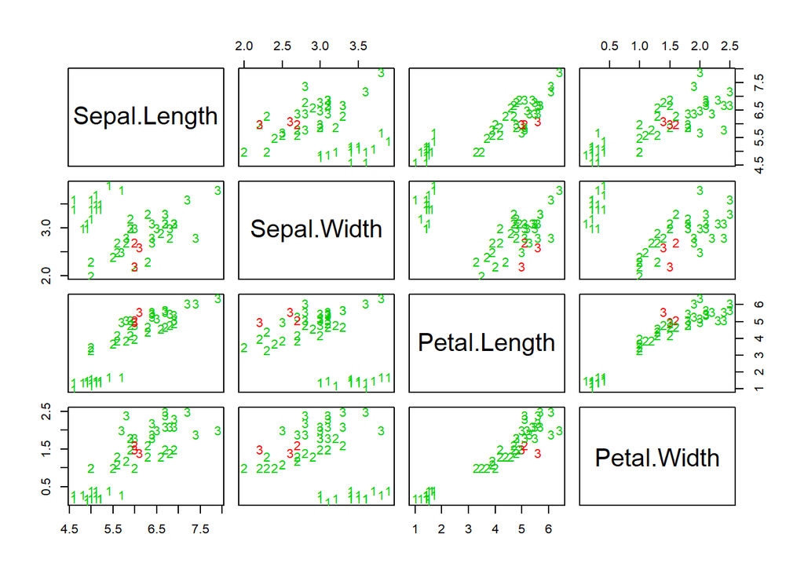

```r
pcol <- as.character(as.numeric(testSet$Species))
pairs(testSet[1:4], pch = pcol,
      col = c("green3", "red")[(testSet$Species != knnmodel.fit) + 1])
```

### 2.3. Đánh giá mô hình

```r
confusion_matrix <- function(predicted, actual) {
  return(table(predicted, actual))
}

accuracy <- function(cm) {
  return(sum(diag(cm))/sum(cm))
}
```

```r
actual <- testSet$Species
cm <- confusion_matrix(knnmodel.fit, actual)
cm
```

```
##             actual
## predicted    setosa versicolor virginica
##   setosa         15          0         0
##   versicolor      0         15         2
##   virginica       0          1        17
```

```r
accuracy(cm)
```

```
## [1] 0.94
```

### 2.4. Đánh giá mô hình dùng phương pháp cross validation

Phần sau đây ta sẽ tiến hành đánh giá theo phương pháp cross validation (thay vì phương pháp holdout như ở trên) với các giá trị k (trong k-nn) khác nhau để tìm ra giá trị k tốt nhất. Đầu tiên ta sẽ tạo các fold, sau đó ta sẽ thử nghiệm trên các fold này với các giá trị k khác nhau.

```r
set.seed(1111)
nfolds <- 3 # số fold
ids <- 1:nrow(iris)
index <- sample(ids) # xao tron ngau nhien ids
fold <- rep(1:nfolds, each = nrow(iris)/nfolds)
folds <- split(index, fold) # tao mot danh sach voi cac index cho moi fold
ks <- seq(1, 19, 2) # k = 1, 3, 5, ..., 19
accs <- matrix(0, nrow = length(ks), ncol = nfolds + 1)
for (k in 1:length(ks)) {
  s = 0
  for (i in 1:nfolds) {
    t <- kknn(Species ~ .,
              train = iris[-folds[[i]], ],
              test = iris[folds[[i]], ],
              k = k,
              distance = 2,
              kernel = "rectangular")
    cm <- confusion_matrix(fitted(t), iris[folds[[i]], 5])
    a <- accuracy(cm)
    s = s + a
    accs[k, i] = a
  }
  accs[k, nfolds + 1] = s / nfolds
}
rownames(accs) <- paste ("k = ", ks, sep = "")
colnames(accs) <- c(paste("fold ", 1:nfolds, sep = ""), "average")
accs
```

```
##        fold 1 fold 2 fold 3   average
## k = 1    0.94   0.92   0.98 0.9466667
## k = 3    0.94   0.92   0.98 0.9466667
## k = 5    0.94   0.94   0.96 0.9466667
## k = 7    0.94   0.94   0.96 0.9466667
## k = 9    0.94   0.94   0.94 0.9400000
## k = 11   0.94   0.94   0.94 0.9400000
## k = 13   0.94   0.98   0.96 0.9600000
## k = 15   0.94   0.98   0.96 0.9600000
## k = 17   0.96   0.96   0.96 0.9600000
## k = 19   0.96   0.96   0.96 0.9600000
```

### 2.5. Trực quan hóa kết quả

Vẽ đồ thị kết quả average accuracy theo k

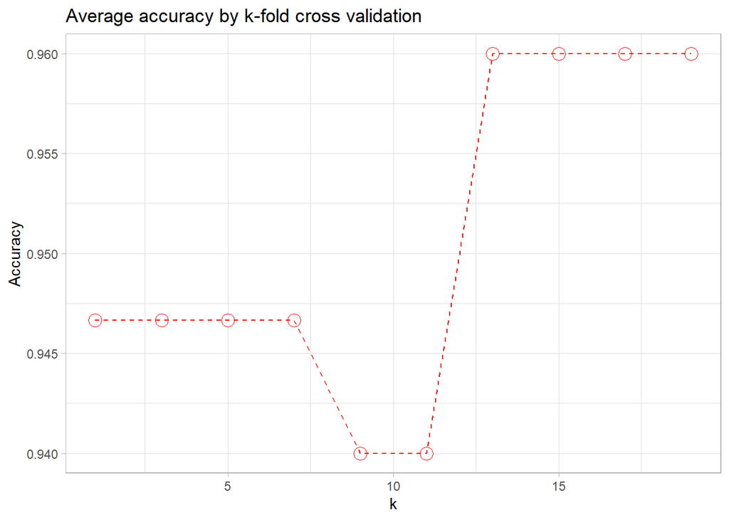

```r
library(ggplot2)
data <- data.frame(k = ks, r = as.numeric(accs[, nfolds + 1]))
ggplot(data = data, mapping = aes(x = k, y = r)) +
  theme_light() +
  ggtitle("Average accuracy by k-fold cross validation") +
  xlab("k") +
  ylab("Accuracy") +
  geom_point(colour = "red", size = 4, shape = 21, fill = "white") +
  geom_line(colour = "red", linetype = "dashed", fill = "white")
```

## 3. Thuật toán cây quyết định

Có nhiều package cài đặt thuật toán cây quyết định (như `tree`, `party`, `rpart`, `C50`, …). Ta sẽ dùng thư viện `party` cho ví dụ minh họa dưới đây. Ta cần cài đặt (nếu chưa cài) và load thư viện `party` trước khi sử dụng như sau:

```r
#install.packages("party")
library(party)
```

### 3.1. Xây dựng mô hình

Ta sẽ dùng tập train và tập test đã tạo ở trên để tạo và đánh giá cây quyết định. Sử dụng `?ctree` để xem thông tin chi tiết về các tham số của hàm `ctree`.

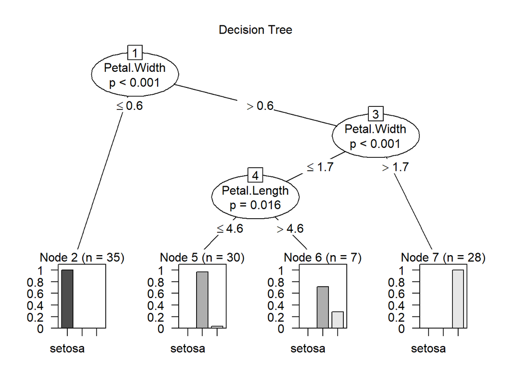

```r
dtmodel <- ctree(Species ~ ., data = trainSet) # Xây dựng cây
plot(dtmodel, main = "Decision Tree") # Vẽ cây
```

### 3.2. Dự đoán kết quả trên tập test

```r
predicted <- predict(dtmodel, testSet)
```

### 3.3. Đánh giá mô hình

Để đánh giá độ chính xác của cây quyết định trên test data ta có thể làm như sau:

```r
actual <- as.character(testSet$Species) # Nhãn/lớp thật sự
predicted <- as.character(predicted)
cm <- confusion_matrix(predicted, actual)
cm
```

[output not shown]

```r
accuracy(cm)
```

```
## [1] 0.94
```

### 3.4. Trực quan hóa kết quả cho tập train

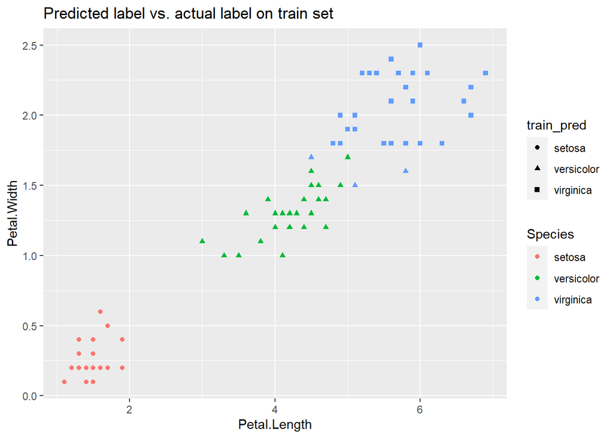

```r
library(ggplot2)

train_pred = as.character(predict(dtmodel, trainSet))

ggplot(data = trainSet,
       mapping = aes(x = Petal.Length,
                     y = Petal.Width,
                     color = Species,
                     shape = train_pred)) +
  geom_point() +
  ggtitle("Predicted label vs. actual label on train set")
```

### 3.5. Trực quan hóa kết quả cho tập test

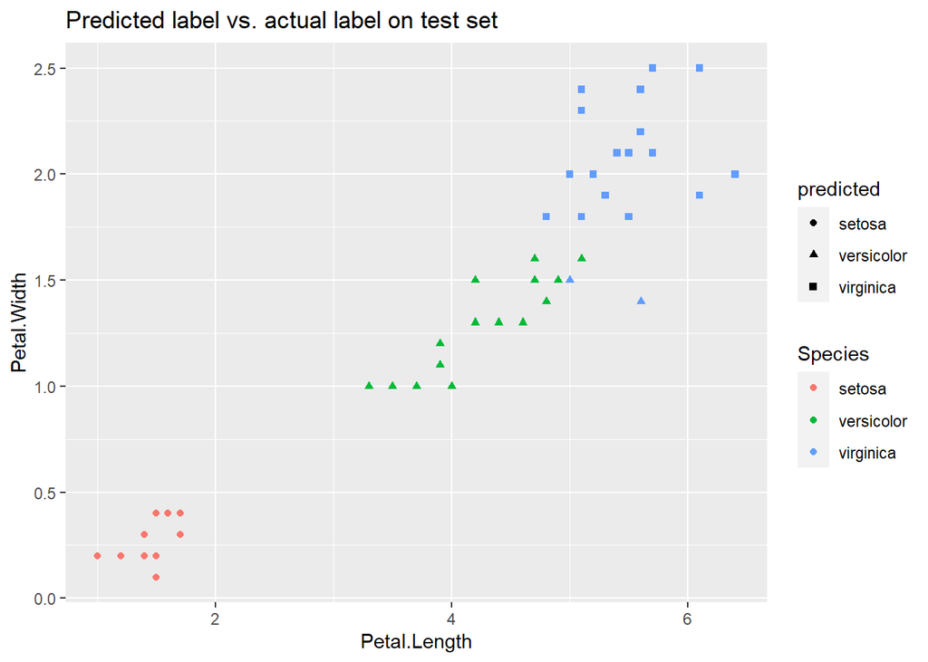

```r
library(ggplot2)

ggplot(data = testSet,
       mapping = aes(x = Petal.Length,
                     y = Petal.Width,
                     color = Species,
                     shape = predicted)) +
  geom_point() +
  ggtitle("Predicted label vs. actual label on test set")
```

## 4. Thử nghiệm với các thuật toán khác

### 4.1. Thuật toán Naive Bayes

Đầu tiên, ta cần cài đặt một thư viên có hiện thực thuật toán Naive Bayes. Thư viện `e1071` là một thư viện như vậy. Ta có thể cài đặt (nếu chưa cài) và load thư viện `e1071` trước khi sử dụng như sau:

```r
#install.packages("e1071")
library(e1071)
```

#### 4.1..1 Xây dựng mô hình

Ta sẽ dùng lại tập train và tập test của tập dữ liệu `iris` đã tạo ở trên để đánh thuật toán Naive Bayes. Sử dụng `?naiveBayes` để xem thông tin chi tiết về các tham số của hàm `naiveBayes`.

```r
nbmodel <- naiveBayes(Species ~ ., data = trainSet)
```

#### 4.1.2. Dự đoán kết quả trên tập test

```r
predicted <- predict(nbmodel, testSet)
```

#### 4.1.3. Đánh giá mô hình

```r
cm <- table(predicted, testSet$Species)
cm
```

```
##
## predicted    setosa versicolor virginica
##   setosa         15          0         0
##   versicolor      0         14         2
##   virginica       0          2        17
```

```r
accuracy(cm)
```

```
## [1] 0.92
```

### 4.2. (Multinominal) Logistic Regression

#### 4.2.1. Xây dựng mô hình

```r
library(nnet)

mlrmodel = nnet::multinom(Species ~ ., data = trainSet)
```

#### 4.2.2. Dự đoán kết quả trên tập test

```r
predicted = predict(mlrmodel, testSet[-5])
```

#### 5.2.3. Đánh giá mô hình

```r
cm <- table(predicted, testSet$Species)
cm
```

```
##
## predicted    setosa versicolor virginica
##   setosa         15          0         0
##   versicolor      0         14         0
##   virginica       0          2        19
```

```r
accuracy(cm)
```

```
## [1] 0.96
```

### 4.3. Support Vector Machine (SVM)

#### 4.3.1. Xây dựng mô hình

```r
library(e1071)

svmmodel = svm(formula = Species ~ .,
                 data = trainSet,
                 type = 'C-classification',
                 kernel = 'linear')
```

#### 4.3.2. Dự đoán kết quả trên tập test

```r
predicted = predict(svmmodel, testSet[-5])
```

#### 4.3.3. Đánh giá mô hình

```r
cm <- table(predicted, testSet$Species)
cm
```

```
##
## predicted    setosa versicolor virginica
##   setosa         15          0         0
##   versicolor      0         14         0
##   virginica       0          2        19
```

```r
accuracy(cm)
```

```
## [1] 0.96
```

## 5. Lựa chọn mô hình

Ta sẽ dùng thư viện `caret` để thực hiện việc tinh chỉnh siêu tham số và lựa chọn mô hình cho các thuật toán. Bên dưới là một minh họa cho việc lựa chọn mô hình cho thuật toán random forest với cross validation với dùng phương pháp grid search.

Tham khảo: https://topepo.github.io/caret/random-hyperparameter-search.html

```r
library(caret)
set.seed(1111)
inTraining <- createDataPartition(iris$Species, p = 0.8, list = FALSE)
training <- iris[ inTraining,]
testing  <- iris[-inTraining,]

fitControl <- trainControl(method = "cv",
                           number = 5,
                           classProbs = TRUE,
                           search = "grid")

set.seed(2222)
rf_fit <- train(Species ~ ., data = training,
                  method = "rf",
                  metric = "Accuracy",
                  tuneLength = 20,
                  trControl = fitControl)
rf_fit
```

```
## Random Forest
##
## 120 samples
##   4 predictor
##   3 classes: 'setosa', 'versicolor', 'virginica'
##
## No pre-processing
## Resampling: Cross-Validated (5 fold)
## Summary of sample sizes: 96, 96, 96, 96, 96
## Resampling results across tuning parameters:
##
##   mtry  Accuracy   Kappa
##   2     0.9333333  0.9
##   3     0.9333333  0.9
##   4     0.9333333  0.9
##
## Accuracy was used to select the optimal model using the largest value.
## The final value used for the model was mtry = 2.
```